# Modelos lineales Ejercicios de la unidad 5 Diagnosis del modelo

Pere López Brosa, Alex Sanchez y Francesc Carmona

7 de Abril de 2018

# Faraway. Capítulo 6.

## Problema 6.1. pág. 97

**Using the `sat` dataset, fit a model with the `total` SAT score as the response and `expend`, `salary`, `ratio` and `takers` as predictors. Perform regression diagnostics on this model to answer the following questions. Display any plots that are relevant. Do not provide any plots about which you have nothing to say. Suggest possible improvements or corrections to the model where appropriate.**

Cargamos los datos y ajustamos el modelo.

```r
> if (!require(faraway)) {
+   install.packages("faraway")
+   require(faraway)
+ }
```

```r
> data(sat,package="faraway")
> head(sat)
```

|  | expend | ratio | salary | takers | verbal | math | total |
| --- | --- | --- | --- | --- | --- | --- | --- |
| Alabama | 4.405 | 17.2 | 31.144 | 8 | 491 | 538 | 1029 |
| Alaska | 8.963 | 17.6 | 47.951 | 47 | 445 | 489 | 934 |
| Arizona | 4.778 | 19.3 | 32.175 | 27 | 448 | 496 | 944 |
| Arkansas | 4.459 | 17.1 | 28.934 | 6 | 482 | 523 | 1005 |
| California | 4.992 | 24.0 | 41.078 | 45 | 417 | 485 | 902 |
| Colorado | 5.443 | 18.4 | 34.571 | 29 | 462 | 518 | 980 |

```r
> model <- lm(total~expend+ratio+salary+takers, data=sat)
> sumary(model)
```

```
              Estimate Std. Error  t value  Pr(>|t|)
(Intercept) 1045.97154   52.86976  19.7839 < 2.2e-16
expend         4.46259   10.54653   0.4231    0.6742
ratio         -3.62423    3.21542  -1.1271    0.2657
salary         1.63792    2.38725   0.6861    0.4962
takers        -2.90448    0.23126 -12.5594 2.607e-16

n = 50, p = 5, Residual SE = 32.70199, R-Squared = 0.82
```

### a) Varianza constante

**Check the constant variance assumption for the errors.**

Representamos los valores absolutos de los residuos porque ahora no estamos interesados en la estructura del modelo (esto será en el último apartado) sino en la magnitud de la varianza.

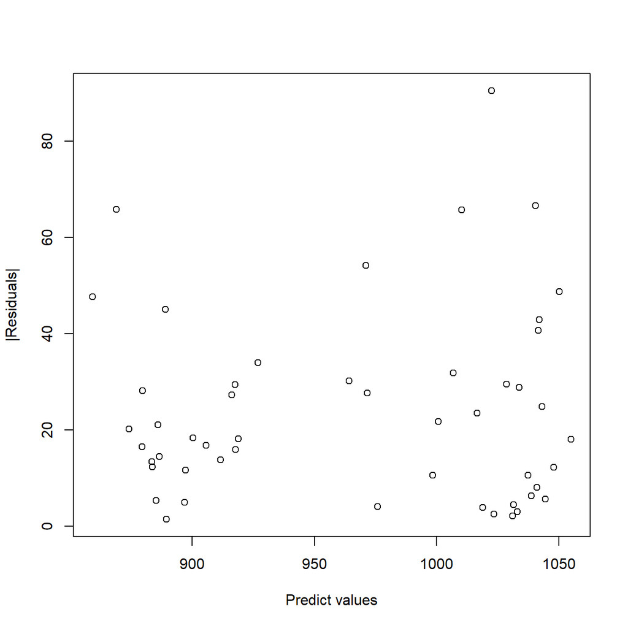

```r
> plot(fitted(model),abs(residuals(model)),xlab="Predict values",ylab="|Residuals|")
```

No hay indicios de que la varianza de los errores dependa del valor ajustado. Aunque no es necesario, podemos comprobarlo también ajustando una recta a los valores absolutos de los residuos (o sus raíces cuadradas) y los valores predichos.

```r
> sumary(lm(sqrt(abs(residuals(model)))~fitted(model)))
```

```
                Estimate Std. Error t value Pr(>|t|)
(Intercept)    4.6484524  4.0660807  1.1432   0.2586
fitted(model) -0.0001637  0.0041994 -0.0390   0.9691

n = 50, p = 2, Residual SE = 1.99717, R-Squared = 0
```

El $p$-valor de la pendiente obtenido ($> 0.05$) indica que no hemos encontrado una relación significativa.

###b) Normalidad **Check the normality assumption.**

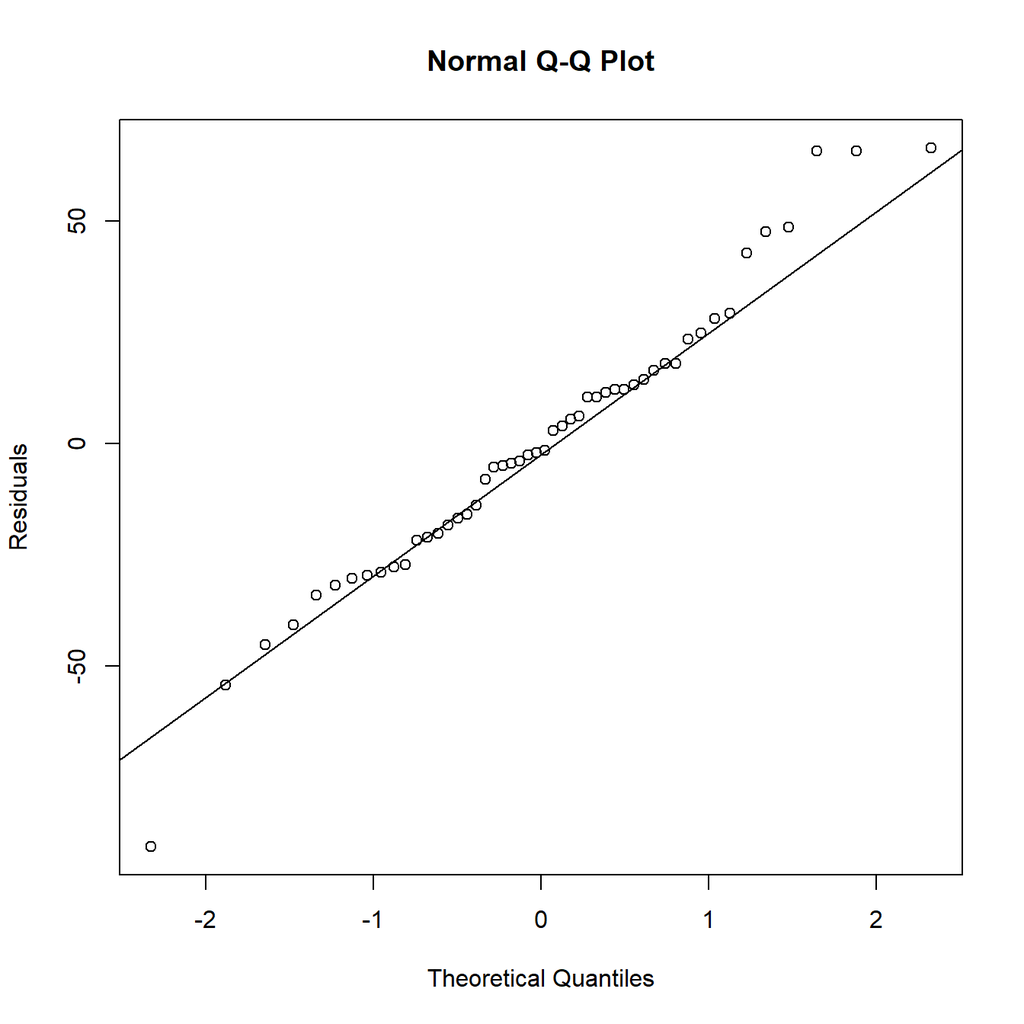

```r
> qqnorm(residuals(model),ylab="Residuals")
> qqline(residuals(model))
```

```r
> shapiro.test(residuals(model))
```

```
    Shapiro-Wilk normality test

data:  residuals(model)
W = 0.97691, p-value = 0.4304
```

No vemos que la distribución de los residuos se aparte mucho de la normal. Incluso uno de los contrastes específicos tampoco encuentra una diferencia significativa.

###c) Leverage **Check for large leverage points.**

Calculamos el *leverage* de cada observación y mostramos los mayores:

```r
> hatv <- hatvalues(model)
> head(sort(hatv,decreasing=T))
```

```
       Utah  California Connecticut  New Jersey    New York      Alaska
  0.2921128   0.2821179   0.2254519   0.2220978   0.1915752   0.1803061
```

El valor medio de los *leverages* es $p/n$ (con $p$ el número de parámetros y $n$ el número de observaciones) y como referencia podemos considerar anómalas las observacions con *leverages* del doble de este valor ($0.2$ para este modelo).

```r
> p <- length(model$coefficients) # k+1
> n <- length(model$fitted.values)
> leverage.mean <- p/n # (k+1)/n
> which(hatv > 2*leverage.mean)
```

```
 California Connecticut  New Jersey        Utah
          5           7          30          44
```

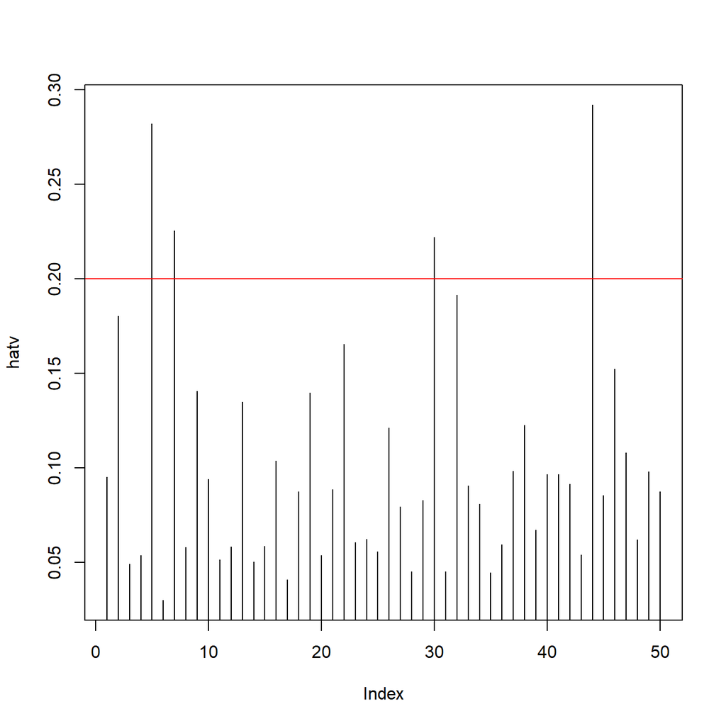

```r
> plot(hatv, type="h")
> abline(h=2*leverage.mean, col="red")
```

Para identificar los valores más grandes también podemos representar los *leverages* contra los cuantiles de una distribución seminormal. Para poder etiquetar las observaciones creamos un vector con el nombre de los estados que utilizaremos en los siguientes apartados.

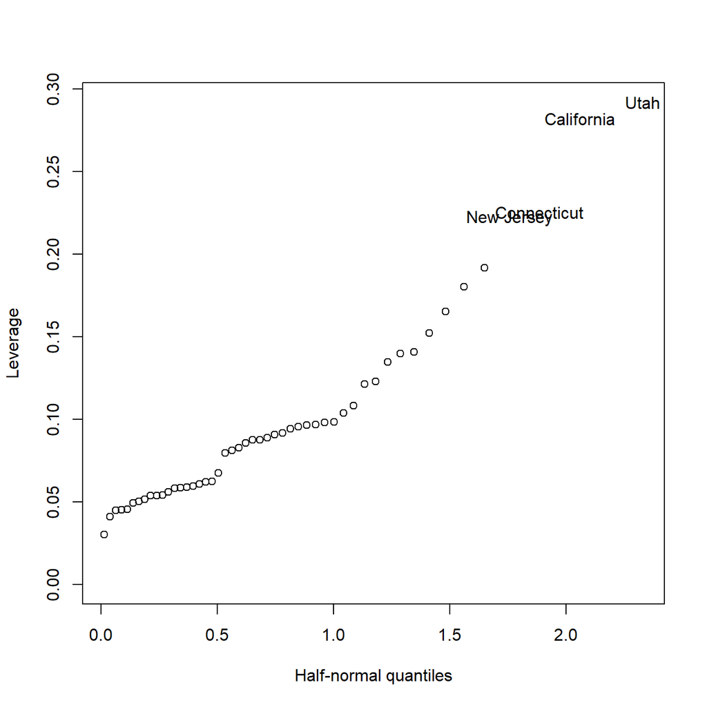

```r
> estados <- row.names(sat)
> halfnorm(hatv,labs=estados,nlab = 4,ylab="Leverage")
```

Las observaciones con *leverages* unusualmente grandes son las de Utah y California, seguidas de Connecticut y Nueva Jersey.

### d) Valores atípicos (outliers)

**Check for outliers.**

Buscamos los estados con un mayor residuo studentizado externamente (*jackknife residual*).

```r
> stud <- rstudent(model)
> head(sort(abs(stud),decreasing=TRUE))
```

```
West Virginia          Utah  North Dakota New Hampshire        Nevada
     3.124428      2.529587      2.213686      2.190006      1.732004
         Iowa
     1.560374
```

Dado que la distribución de estos residuos es una $t$ de Student con $n-p-1=50-5-1=44$ grados de libertad, podemos utilizar el criterio naíf de considerar outlier todo residuo con valor absoluto superior a $2$.

```r
> which(abs(stud)>2)
```

```
New Hampshire  North Dakota          Utah West Virginia
           29            34            44            48
```

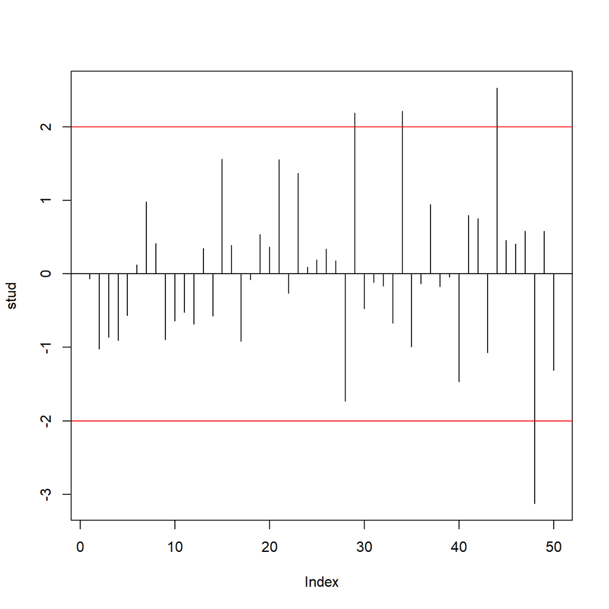

```r
> plot(stud, type="h")
> abline(h=-2, col="red"); abline(h=0); abline(h=2, col="red")
```

O ser más sofisticados y considerar el valor crítico de la $t$ de Student y la corrección de Bonferroni para comparaciones múltiples.

```r
> grlib <- n-p-1
> which(abs(stud) > abs(qt(0.05/(2*n),grlib)))
```

```
named integer(0)
```

Vemos que con este último criterio todos los residuos quedan por debajo del valor crítico y que no hallamos ningún valor atípico. Queda la duda de si puede haber grupos de valores atípicos que no hayamos sabido encontrar.

###e) Observaciones influyentes **Check for influential points.**

Calculamos la distancia de Cook como medida de la influencia de los puntos y la representamos contra los cuartiles de una distribución seminormal.

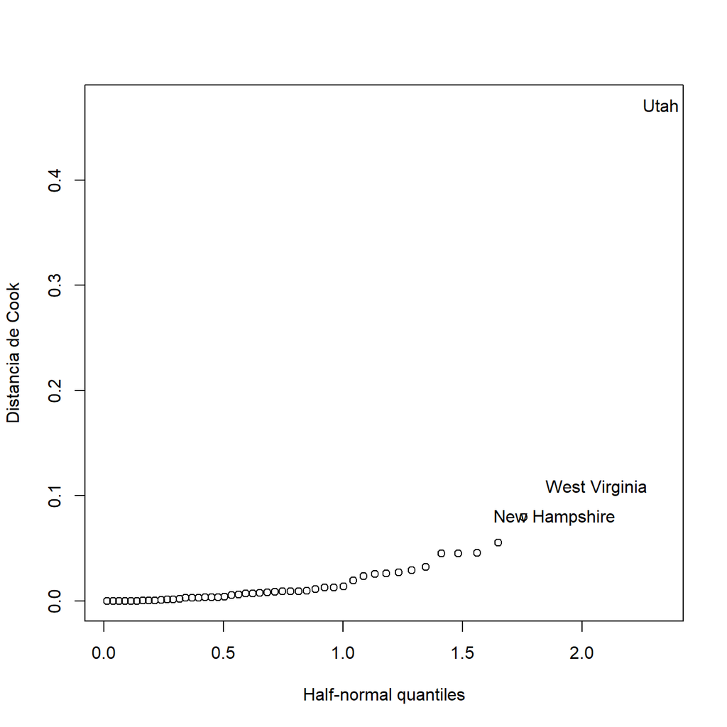

```r
> cook <- cooks.distance(model)
> halfnorm(cook,nlab=3,labs=estados,ylab="Distancia de Cook")
```

En el siguiente gráfico se muestra un criterio de selección:

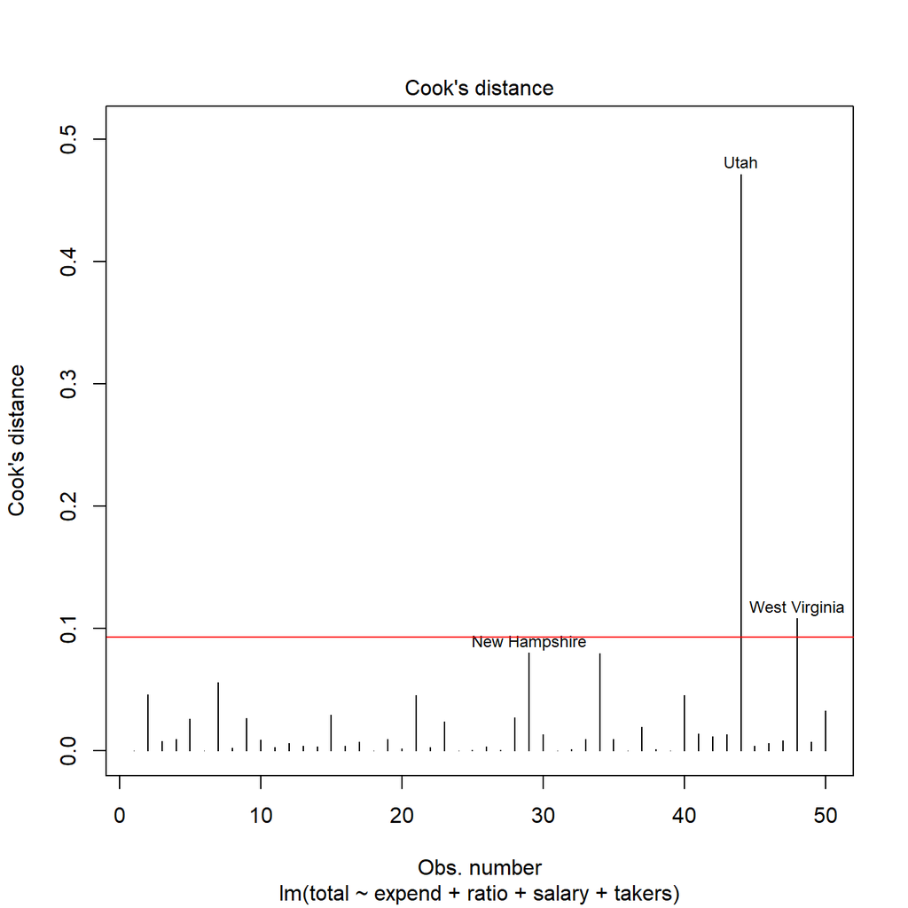

```r
> # Cook's D plot
> # identify D values > 4/(n-k-1)
> plot(model, which=4)
> abline(h=4/((n-p-2)), col="red")
```

###f) Estructura de la relación predictores-respuesta **Check the structure of the relationship between the predictors and the response.**

Podemos comprobar también si la distribución de los errores depende de los predictores. El único que presenta señales de anomalías es la variable `takers`:

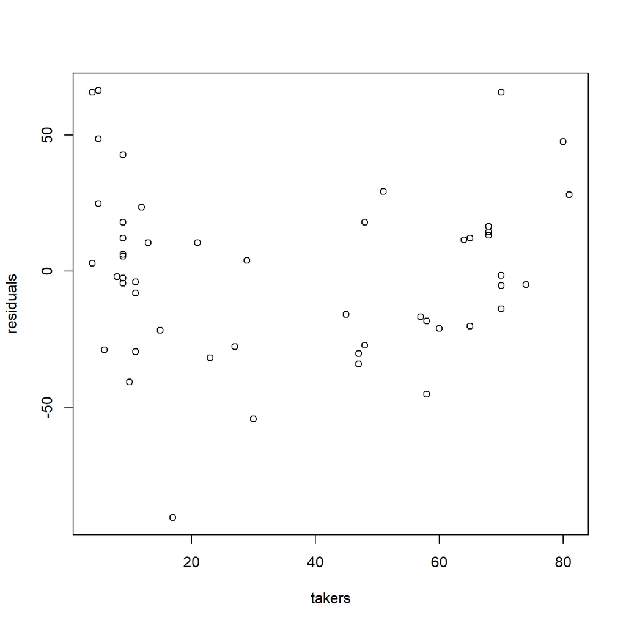

```r
> plot(sat$takers,residuals(model),xlab="takers",ylab="residuals")
```

Vemos que los residuos tienden a ser mayores para los valores no intermedios de `takers` y menores para los intermedios. Esto puede ser un indicio de no linealidad. Como la forma del diagrama de dispersión de los errores sugiere una parábola intentamos añadir al modelo un término `takers^2`:

```r
> model2 <- lm(total~expend+ratio+salary+takers+I(takers^2),data=sat)
> sumary(model2)
```

```
               Estimate  Std. Error t value  Pr(>|t|)
(Intercept) 1014.423279   43.044983 23.5666 < 2.2e-16
expend         9.111663    8.545251  1.0663    0.2921
ratio          2.139912    2.831709  0.7557    0.4539
salary        -0.077699    1.952878 -0.0398    0.9684
takers        -6.709155    0.778204 -8.6213 5.265e-11
I(takers^2)    0.051834    0.010294  5.0354 8.576e-06

n = 50, p = 6, Residual SE = 26.34145, R-Squared = 0.89
```

Comprobamos que el ajuste ha mejorado y que el termino `takers^2` es significativo.

## Problema 6.2. pág. 97

**Using the `teengamb` dataset, fit a model with `gamble` as the response and the other variables as predictors. Answer the questions posed in the previous question.**

Podéis ver en el problema 6.1. comentarios detallados sobre los procedimientos. Para evitar repeticiones aquí comentaremos tan sólo las diferencias con el problema 6.1 y los resultados.

Cargamos los datos y ajustamos el modelo.

```r
> require(faraway)
```

```r
> data(teengamb,package="faraway")
> head(teengamb)
```

| sex | status | income | verbal | gamble |
| --- | --- | --- | --- | --- |
| 1 | 51 | 2.00 | 8 | 0.0 |
| 1 | 28 | 2.50 | 8 | 0.0 |
| 1 | 37 | 2.00 | 6 | 0.0 |
| 1 | 28 | 7.00 | 4 | 7.3 |
| 1 | 65 | 2.00 | 8 | 19.6 |
| 1 | 61 | 3.47 | 6 | 0.1 |

```r
> model <- lm(gamble~.,data=teengamb)
> sumary(model)
```

```
              Estimate Std. Error t value  Pr(>|t|)
(Intercept)  22.555651  17.196803  1.3116   0.19677
sex         -22.118330   8.211115 -2.6937   0.01011
status        0.052234   0.281112  0.1858   0.85349
income        4.961979   1.025392  4.8391 1.792e-05
verbal       -2.959493   2.172150 -1.3625   0.18031

n = 47, p = 5, Residual SE = 22.69034, R-Squared = 0.53
```

###a) Varianza constante

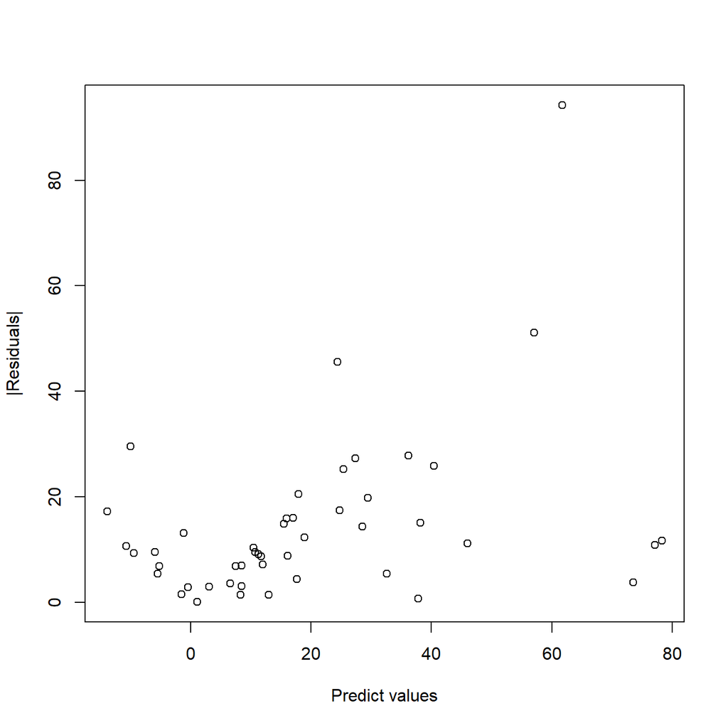

```r
> plot(fitted(model),abs(residuals(model)),xlab="Predict values",ylab="|Residuals|")
```

```r
> sumary(lm(sqrt(abs(residuals(model)))~fitted(model)))
```

```
              Estimate Std. Error t value Pr(>|t|)
(Intercept)   2.878378   0.312183  9.2201 6.21e-12
fitted(model) 0.026790   0.010496  2.5523  0.01417

n = 47, p = 2, Residual SE = 1.62834, R-Squared = 0.13
```

En el gráfico se aprecian residuos más dispersos hacia las observaciones con valores predichos más grandes, con un par de valores muy grandes en esta zona (sobre todo uno), y la regresión de la raíz cuadrada de los errores respecto al valor predicho muestra una dependencia significativa. Podría ser útil plantearnos una transformación de los datos.

Listamos los residuos más grandes (en valor absoluto), y nos fijamos en la observación número 24, ya que la volveremos a encontrar unos apartados más abajo (apartado d, valores atípicos y e, observaciones influyentes).

```r
> head(residuals(model)[order(abs(residuals(model)),decreasing=TRUE)])
```

```
       24        39        36         5        18        23
 94.25222 -51.08241  45.60513  29.51947 -27.79985 -27.27117
```

### b) Normalidad

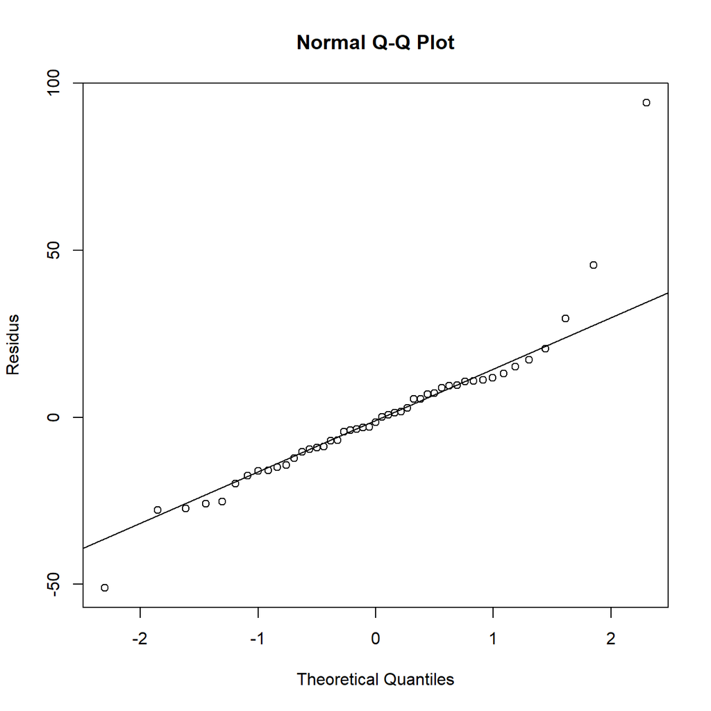

```r
> qqnorm(residuals(model),ylab="Residus")
> qqline(residuals(model))
```

```r
> shapiro.test(residuals(model))
```

```
    Shapiro-Wilk normality test

data:  residuals(model)
W = 0.86839, p-value = 8.16e-05
```

La distribución se aparta de la normal en las colas, que son más largas, sobre todo en la cola de la derecha, lo que concuerda con el hecho de haber visto en el apartado anterior un par de residuos inusualmente grandes. El test de normalidad lo confirma.

### c) Leverage

Calculamos el leverage de cada observación y mostramos los mayores:

```r
> hatv <- hatvalues(model)
> head(sort(hatv,decreasing=T))
```

```
       35        42        31        33         6        17
0.3118029 0.3016088 0.2395031 0.2213439 0.1637856 0.1400034
```

Comparamos con el leverage medio $p/n$:

```r
> p <- length(model$coefficients) # k+1
> n <- length(model$fitted.values)
> leverage.mean <- p/n # (k+1)/n
> which(hatv > 2*leverage.mean)
```

```
31 33 35 42
31 33 35 42
```

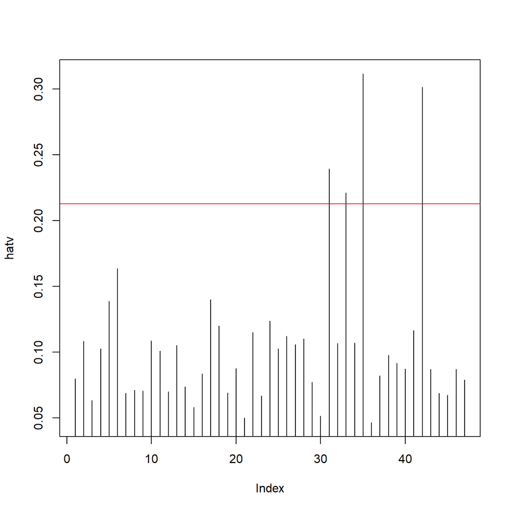

```r
> plot(hatv, type="h")
> abline(h=2*leverage.mean, col="red")
```

Dado que tenemos unos cuantos valores por encima de 2 veces la media los examinamos más detalladamente:

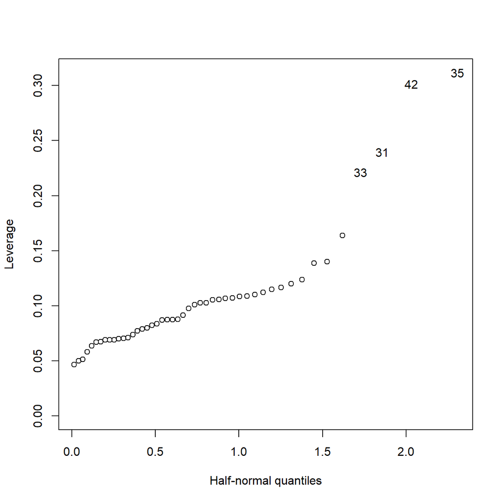

```r
> halfnorm(hatv,nlab=4,ylab="Leverage")
```

Los gráficos nos confirman la conclusión de la tabla anterior con cuatro valores notablemente por encima de la media.

### d) Valores atípicos (outliers)

Buscamos las observaciones con un mayor residuo jackknife.

```r
> stud <- rstudent(model)
> head(sort(abs(stud),decreasing=TRUE))
```

```
      24       39       36        5       18       23
6.016116 2.506090 2.144826 1.418583 1.317398 1.252647
```

```r
> which(abs(stud)>2)
```

```
24 36 39
24 36 39
```

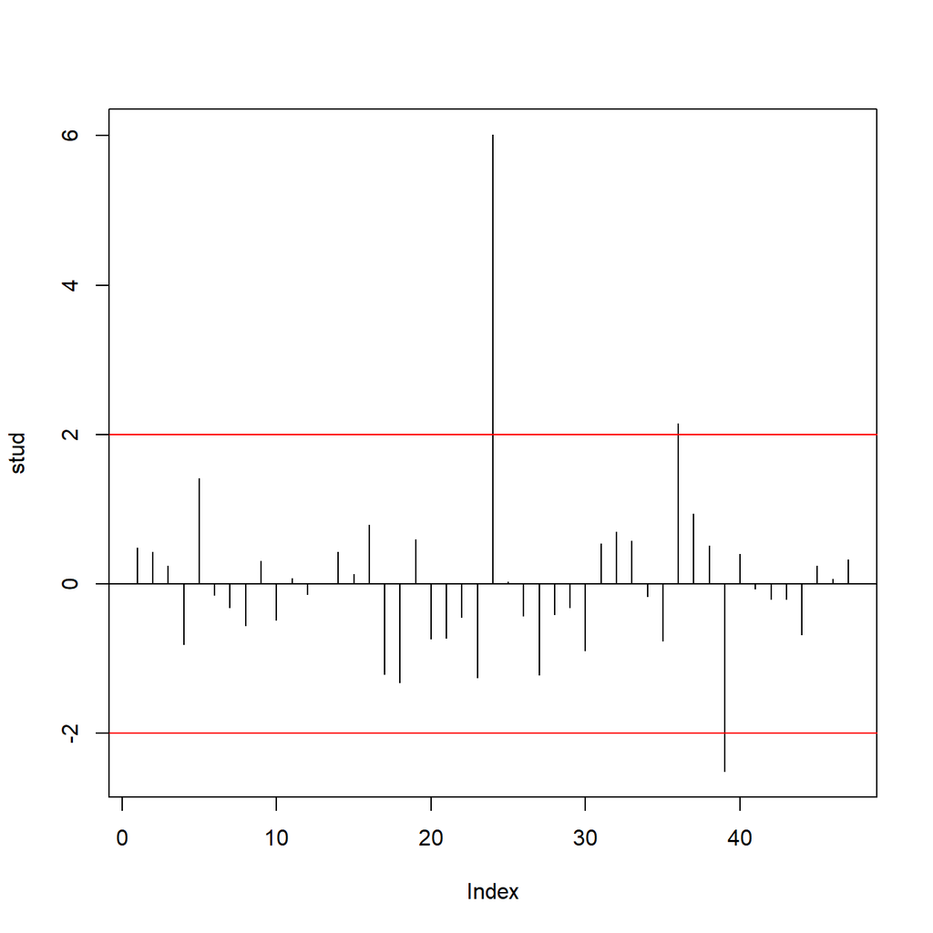

```r
> plot(stud, type="h")
> abline(h=-2, col="red"); abline(h=0); abline(h=2, col="red")
```

*Aplicando la corrección de Bonferroni para comparaciones múltiples el valor crítico será:*

```r
> which(abs(stud) > abs(qt(0.05/(2*n),df=n-p-1)))
```

```
24
24
```

Tenemos una observación bastante por encima del valor crítico (observación 24). De manera nada sorprendente este valor atípico es la misma observación que habíamos detectado con un residuo muy grande en el primer apartado.

###e) Observaciones influeynts **Check for influential points.**

Calculamos la distancia de Cook como medida de la influencia de los puntos y la representamos contra los cuartiles de una distribución seminormal.

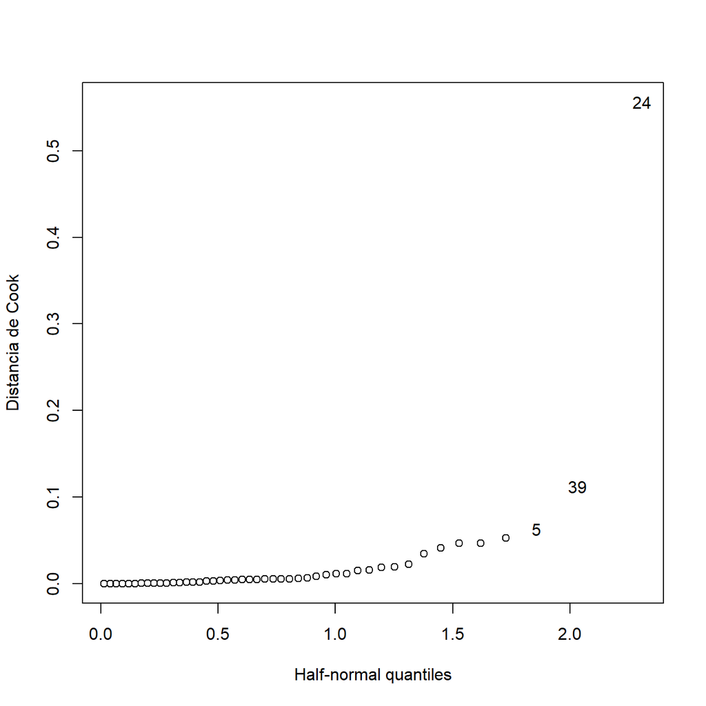

```r
> cook <- cooks.distance(model)
> halfnorm(cook,nlab=3,ylab="Distancia de Cook")
```

Nos volvemos a encontrar con la observación 24, excepcionalmente influyente. Para comprobar cómo afecta el modelo, la ajustamos de nuevo sin esta observación:

```r
> model24 <- lm(gamble~.,data=teengamb[-24,])
> sumary(model24)
```

```
             Estimate Std. Error t value  Pr(>|t|)
(Intercept)   7.63060   12.92506  0.5904   0.55818
sex         -16.29859    6.13346 -2.6573   0.01118
status        0.17387    0.20834  0.8346   0.40880
income        4.33125    0.76358  5.6723 1.265e-06
verbal       -1.80187    1.61374 -1.1166   0.27068

n = 46, p = 5, Residual SE = 16.73689, R-Squared = 0.57
```

*Comparamos con el modelo original:*

```r
> sumary(model)
```

```
              Estimate Std. Error t value  Pr(>|t|)
(Intercept)  22.555651  17.196803  1.3116   0.19677
sex         -22.118330   8.211115 -2.6937   0.01011
status        0.052234   0.281112  0.1858   0.85349
income        4.961979   1.025392  4.8391 1.792e-05
verbal       -2.959493   2.172150 -1.3625   0.18031

n = 47, p = 5, Residual SE = 22.69034, R-Squared = 0.53
```

Vemos que ignorar esta observación produce un cambio importante en los parámetros.

###f) Estructura del modelo

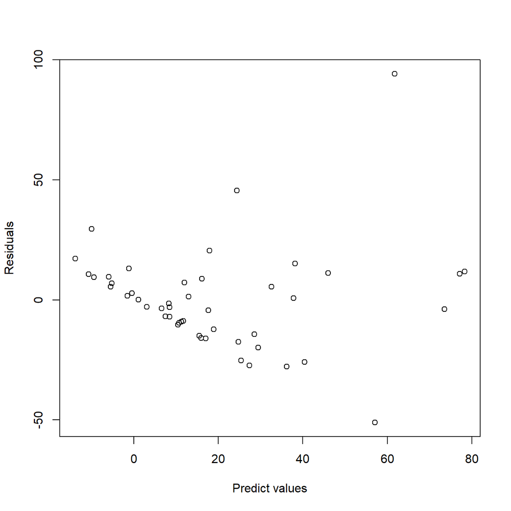

```r
> plot(fitted(model),residuals(model),xlab="Predict values",ylab="Residuals")
```

## Problema 6.3. pág. 97

**For the `prostate` data, fit a model with `lpsa` as the response and the other variables as predictors. Answer the questions posed in the first question.**

Cargamos los datos y ajustamos el modelo.

```r
> require(faraway)
```

```r
> data(prostate,package="faraway")
> head(prostate)
```

| lcavol | lweight | age | lbph | svi | lcp | gleason | pgg45 | lpsa |
| --- | --- | --- | --- | --- | --- | --- | --- | --- |
| -0.5798185 | 2.7695 | 50 | -1.386294 | 0 | -1.38629 | 6 | 0 | -0.43078 |
| -0.9942523 | 3.3196 | 58 | -1.386294 | 0 | -1.38629 | 6 | 0 | -0.16252 |
| -0.5108256 | 2.6912 | 74 | -1.386294 | 0 | -1.38629 | 7 | 20 | -0.16252 |
| -1.2039728 | 3.2828 | 58 | -1.386294 | 0 | -1.38629 | 6 | 0 | -0.16252 |
| 0.7514161 | 3.4324 | 62 | -1.386294 | 0 | -1.38629 | 6 | 0 | 0.37156 |
| -1.0498221 | 3.2288 | 50 | -1.386294 | 0 | -1.38629 | 6 | 0 | 0.76547 |

```r
> model<-lm(lpsa~.,data=prostate)
> sumary(model)
```

```
              Estimate Std. Error t value  Pr(>|t|)
(Intercept)  0.6693367  1.2963875  0.5163  0.606934
lcavol       0.5870218  0.0879203  6.6767 2.111e-09
lweight      0.4544674  0.1700124  2.6731  0.008955
age         -0.0196372  0.0111727 -1.7576  0.082293
lbph         0.1070540  0.0584492  1.8316  0.070398
svi          0.7661573  0.2443091  3.1360  0.002329
lcp         -0.1054743  0.0910135 -1.1589  0.249638
gleason      0.0451416  0.1574645  0.2867  0.775033
pgg45        0.0045252  0.0044212  1.0235  0.308860

n = 97, p = 9, Residual SE = 0.70842, R-Squared = 0.65
```

### a) Varianza constante

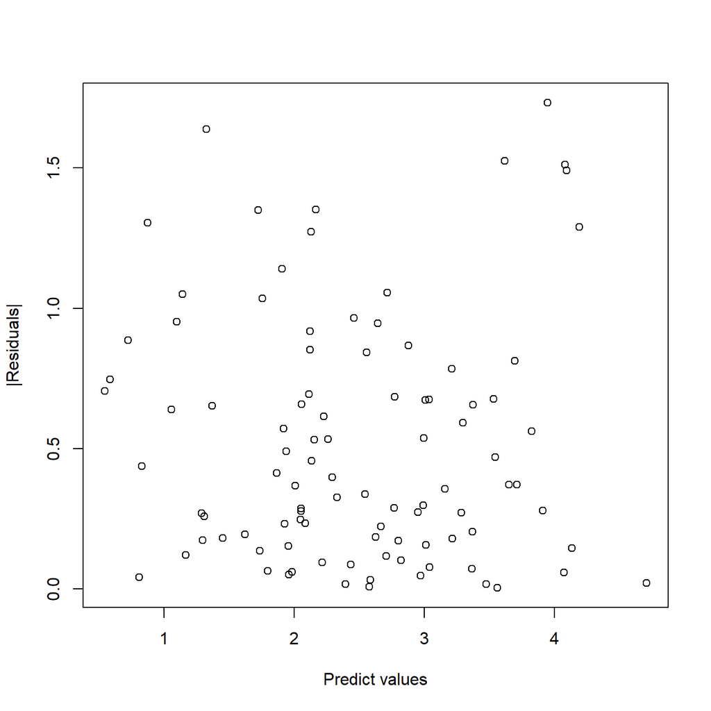

```r
> plot(fitted(model),abs(residuals(model)),xlab="Predict values",ylab="|Residuals|")
```

```r
> sumary(lm(sqrt(abs(residuals(model)))~fitted(model)))
```

```
               Estimate Std. Error t value  Pr(>|t|)
(Intercept)    0.703381   0.090607  7.7630 9.475e-12
fitted(model) -0.021990   0.034232 -0.6424    0.5222

n = 97, p = 2, Residual SE = 0.31328, R-Squared = 0
```

No encontramos indicios de no homogeneidad de la varianza.

### b) Normalidad

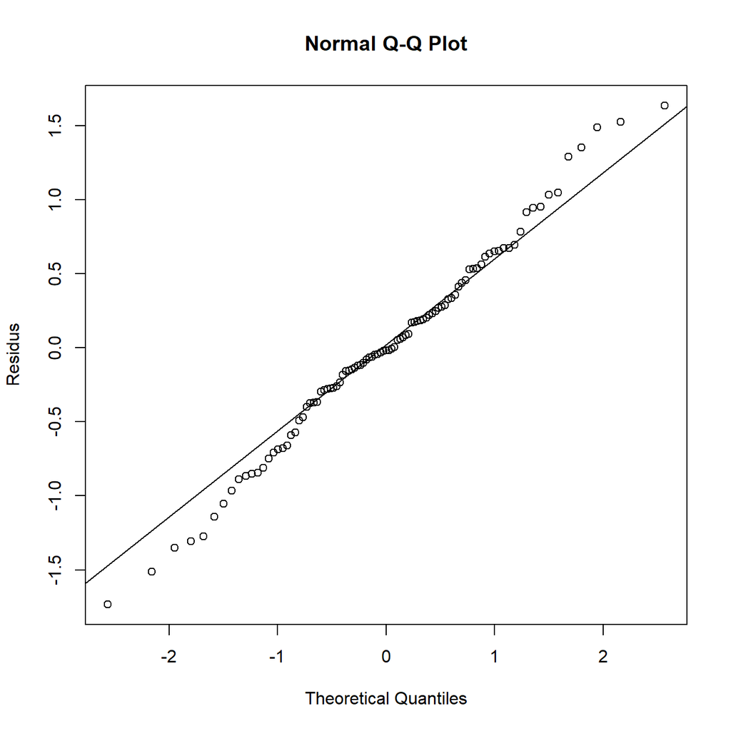

```r
> qqnorm(residuals(model),ylab="Residus")
> qqline(residuals(model))
```

```r
> shapiro.test(residuals(model))
```

```
    Shapiro-Wilk normality test

data:  residuals(model)
W = 0.99113, p-value = 0.7721
```

Hay una cierta desviación respecto a la normal, con las colas algo alargadas.

### c) Leverage

Calculamos el leverage de cada observación y mostramos los mayores:

```r
> hatv <- hatvalues(model)
> head(sort(hatv,decreasing=T))
```

```
       32        41        37        92        74        63
0.3304757 0.2410079 0.2184392 0.2092421 0.1912109 0.1846807
```

Comparamos con dos veces el leverage medio $p/n$:

```r
> p <- length(model$coefficients) # k+1
> n <- length(model$fitted.values)
> which(hatv > 2*p/n)
```

```
32 37 41 74 92
32 37 41 74 92
```

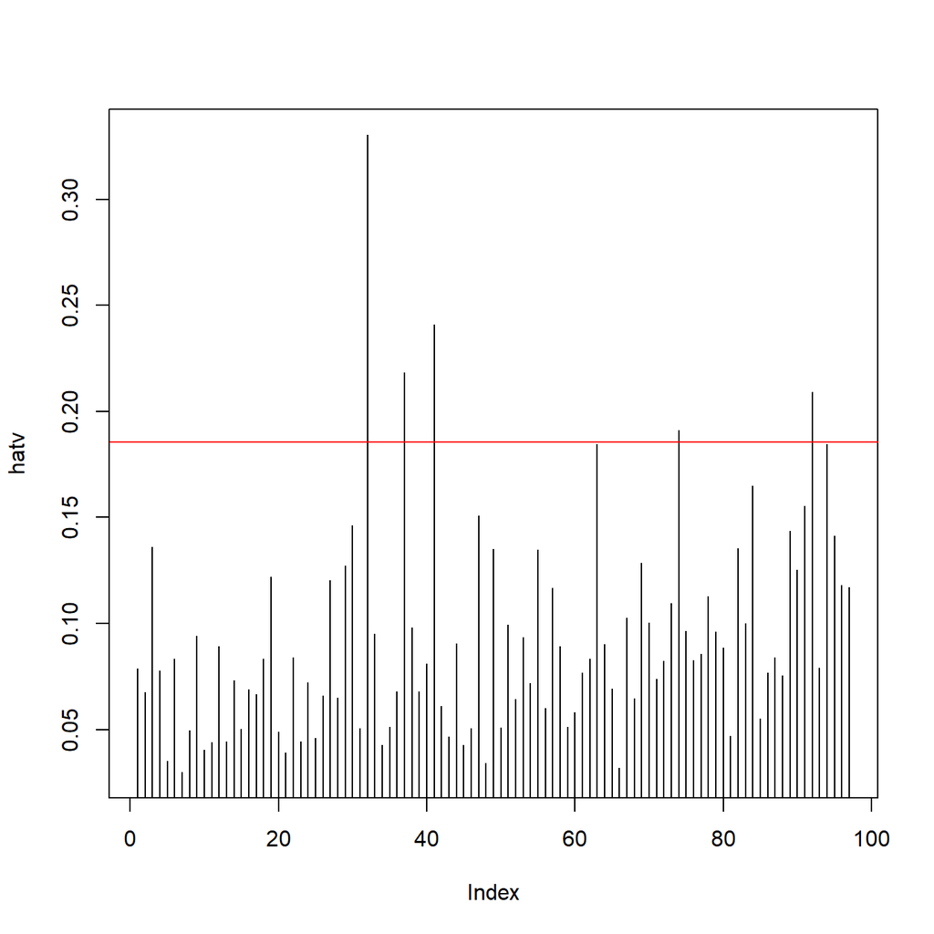

```r
> plot(hatv, type="h")
> abline(h=2*p/n, col="red")
```

### d) Valores atípicos (outliers)

Buscamos las observaciones con un mayor residuo jackknife.

```r
> stud <- rstudent(model)
> head(sort(abs(stud),decreasing=TRUE))
```

```
      39       69       95       47       97       81
2.616980 2.553530 2.385070 2.376671 2.293279 1.987947
```

```r
> which(abs(stud)>2)
```

```
39 47 69 95 97
39 47 69 95 97
```

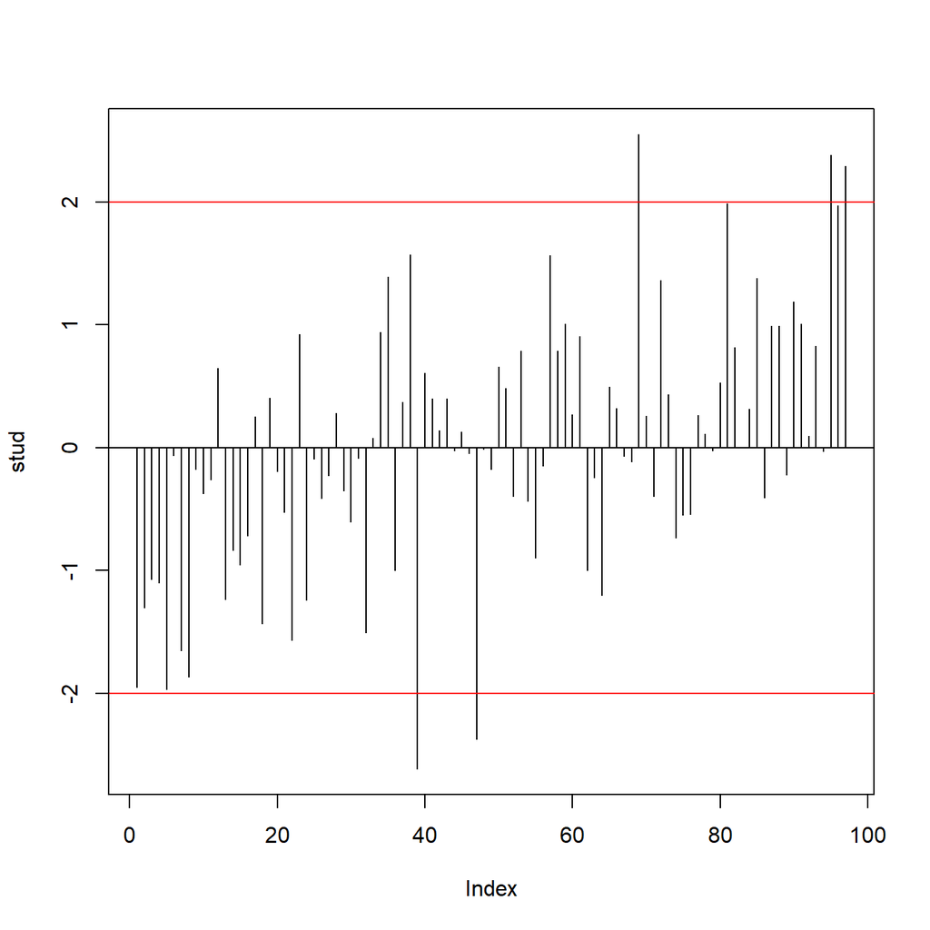

```r
> plot(stud, type="h")
> abline(h=-2, col="red"); abline(h=0); abline(h=2, col="red")
```

Aplicando la corrección de Bonferroni para comparaciones múltiples

```r
> which(abs(stud) > abs(qt(0.05/(2*n),df=n-p-1)))
```

```
named integer(0)
```

no tenemos ninguna observación muy por encima del valor crítico.

### e) Observaciones influyentes

**Check for influential points.**

Calculamos la distancia de Cook como medida de la influencia de los puntos y la representamos contra los cuartiles de una distribución seminormal.

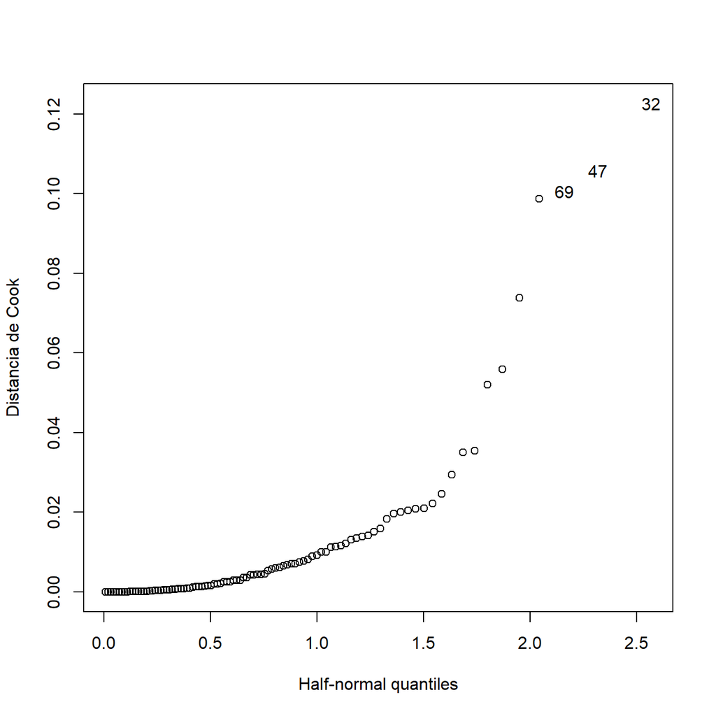

```r
> cook <- cooks.distance(model)
> halfnorm(cook,nlab=3,ylab="Distancia de Cook")
```

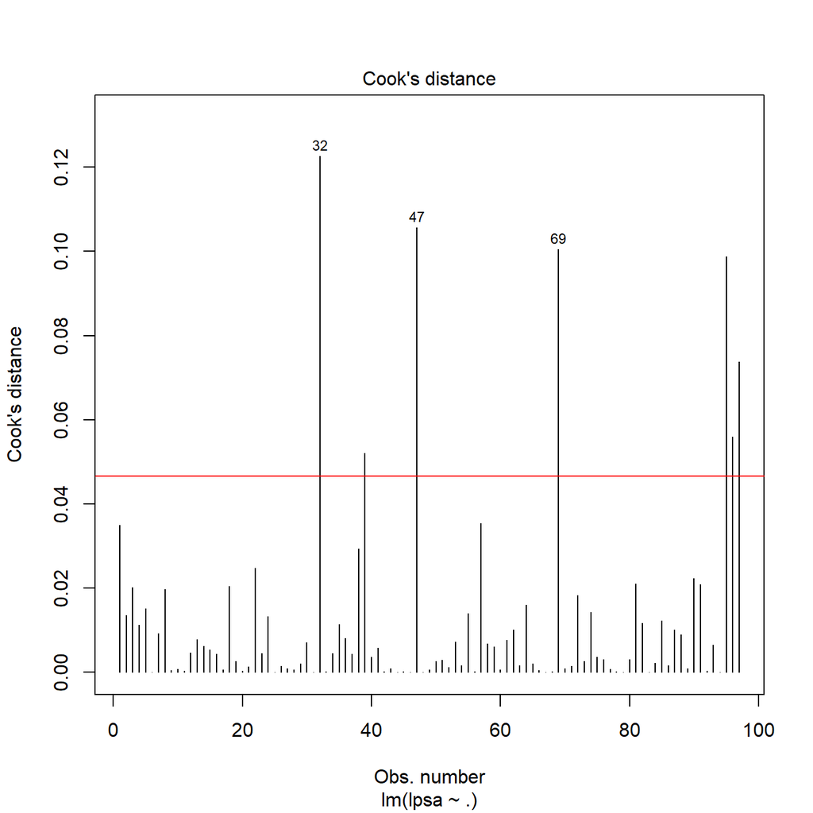

```r
> # Cook's D plot
> # identify D values > 4/(n-k-1)
> plot(model, which=4)
> abline(h=4/((n-p-2)), col="red")
```

Podemos tener una idea de cómo estas observaciones afectan el modelo, la ajustamos de nuevo sin la observación 32:

```r
> model32 <- lm(lpsa~.,data=prostate[-32,])
> sumary(model32)
```

```
              Estimate Std. Error t value Pr(>|t|)
(Intercept)  0.1718627  1.3288221  0.1293 0.897391
lcavol       0.5653328  0.0884722  6.3899 7.93e-09
lweight      0.6216627  0.2020165  3.0773 0.002793
age         -0.0212715  0.0111459 -1.9085 0.059630
lbph         0.0955905  0.0585289  1.6332 0.106037
svi          0.7604232  0.2425957  3.1345 0.002347
lcp         -0.1059870  0.0903647 -1.1729 0.244045
gleason      0.0506884  0.1563842  0.3241 0.746620
pgg45        0.0044683  0.0043898  1.0179 0.311554

n = 96, p = 9, Residual SE = 0.70336, R-Squared = 0.66
```

Comparamos con el modelo original:

```r
> model$call
```

```
lm(formula = lpsa ~ ., data = prostate)
```

```r
> sumary(model)
```

```
              Estimate Std. Error t value  Pr(>|t|)
(Intercept)  0.6693367  1.2963875  0.5163  0.606934
lcavol       0.5870218  0.0879203  6.6767 2.111e-09
lweight      0.4544674  0.1700124  2.6731  0.008955
age         -0.0196372  0.0111727 -1.7576  0.082293
lbph         0.1070540  0.0584492  1.8316  0.070398
svi          0.7661573  0.2443091  3.1360  0.002329
lcp         -0.1054743  0.0910135 -1.1589  0.249638
gleason      0.0451416  0.1574645  0.2867  0.775033
pgg45        0.0045252  0.0044212  1.0235  0.308860

n = 97, p = 9, Residual SE = 0.70842, R-Squared = 0.65
```

Vemos que ignorar esta observación produce un cambio importante en los parámetros aunque sin ser dramático.

### f) Estructura del modelo

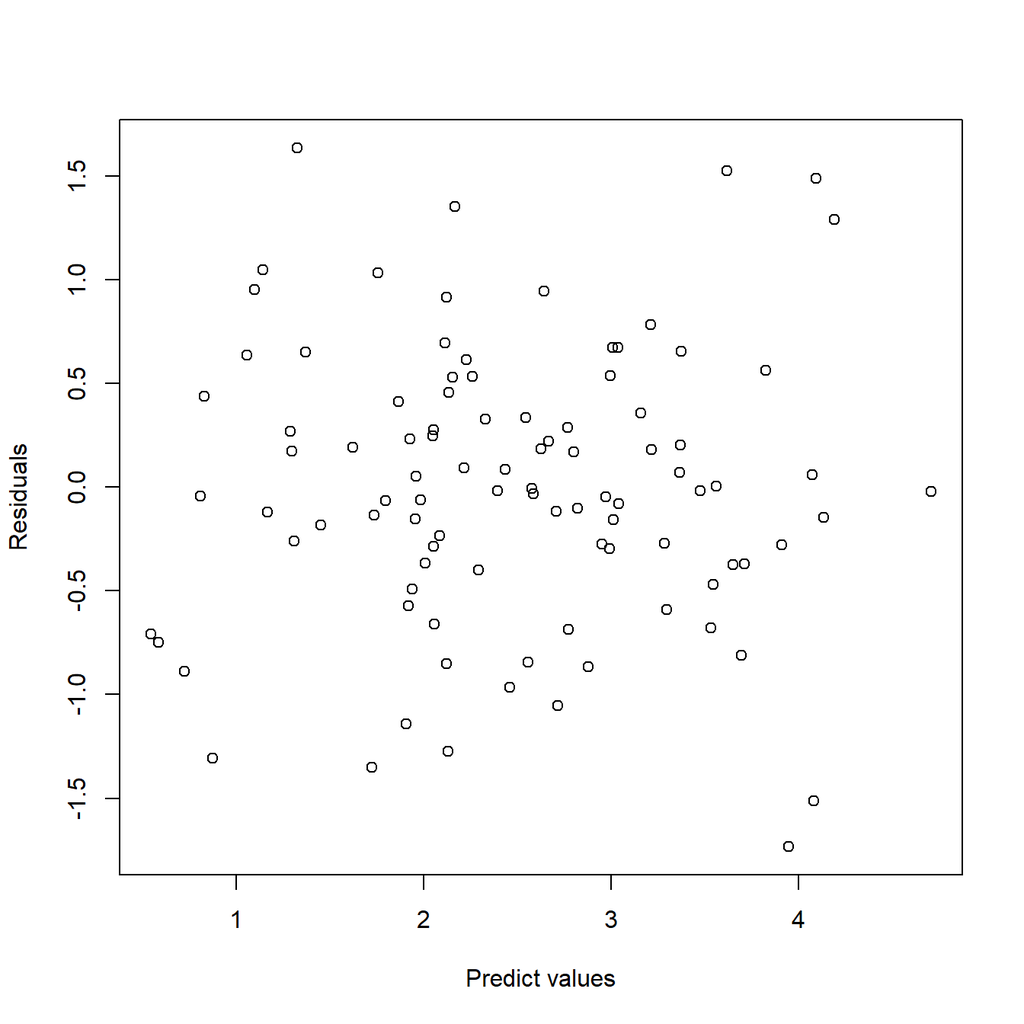

```r
> plot(fitted(model),residuals(model),xlab="Predict values",ylab="Residuals")
```

La observación de los residuos representados con los valores ajustados no da señales de inadecuación del modelo. Observarlos con cada uno de los predictores tampoco:

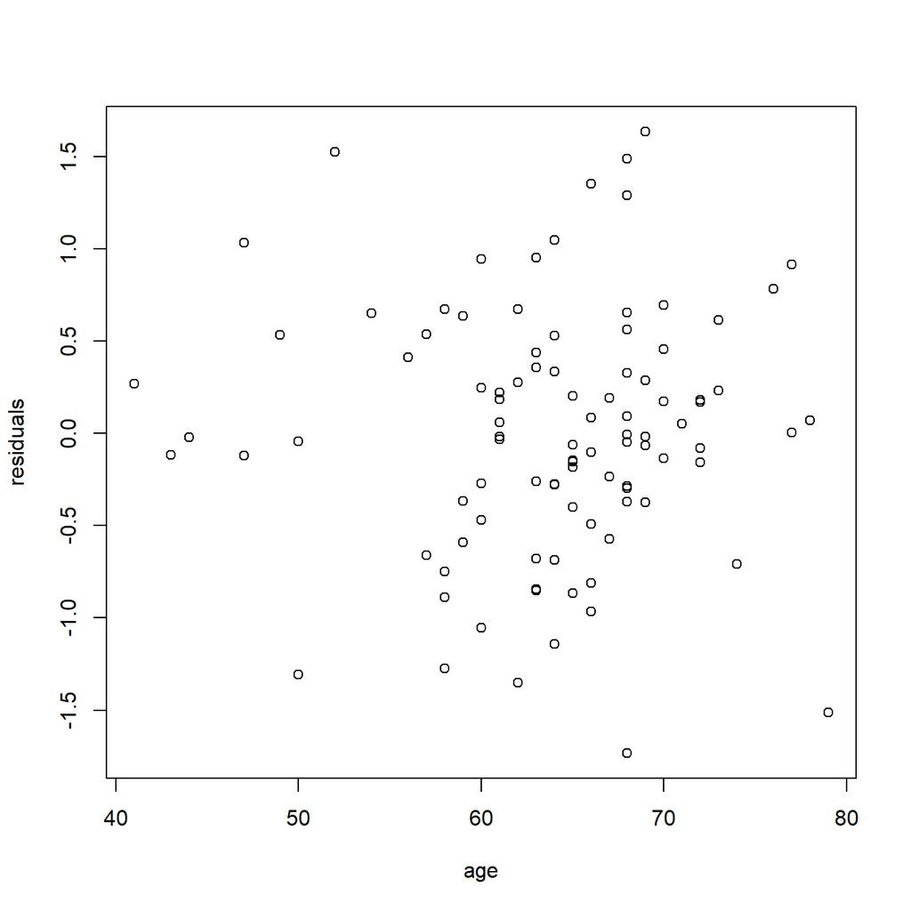

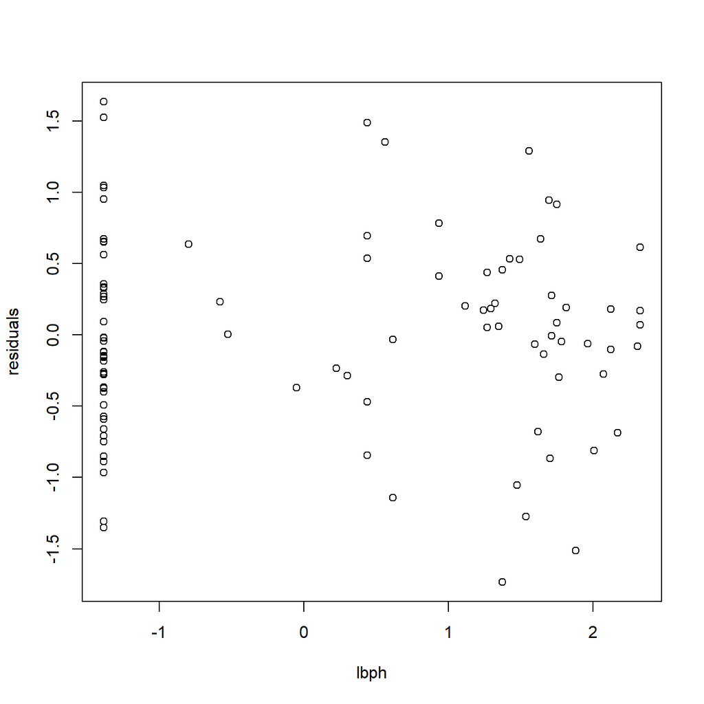

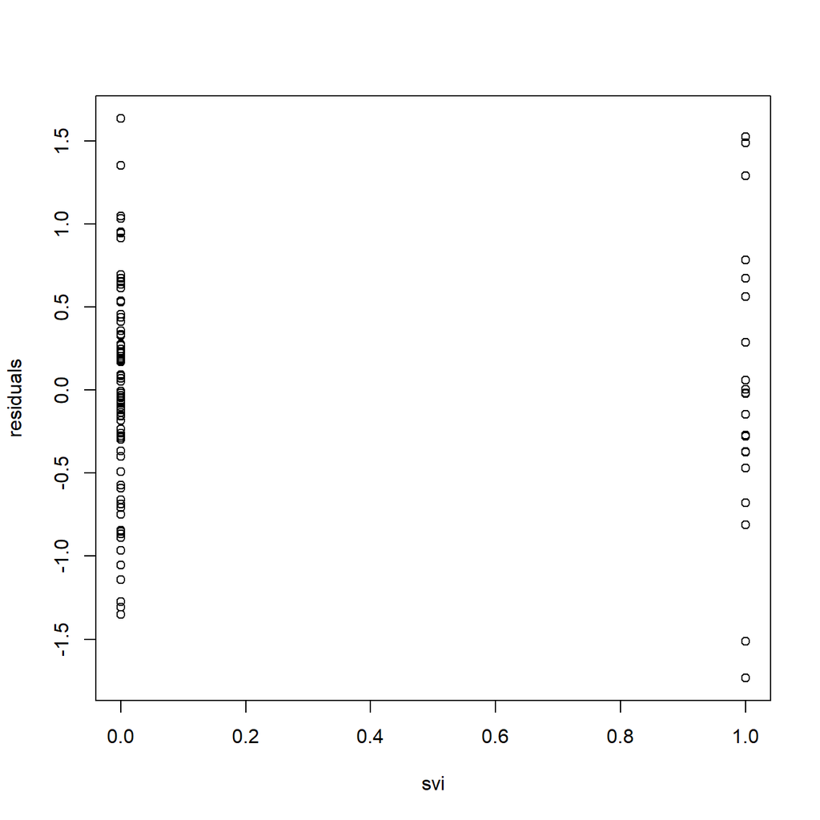

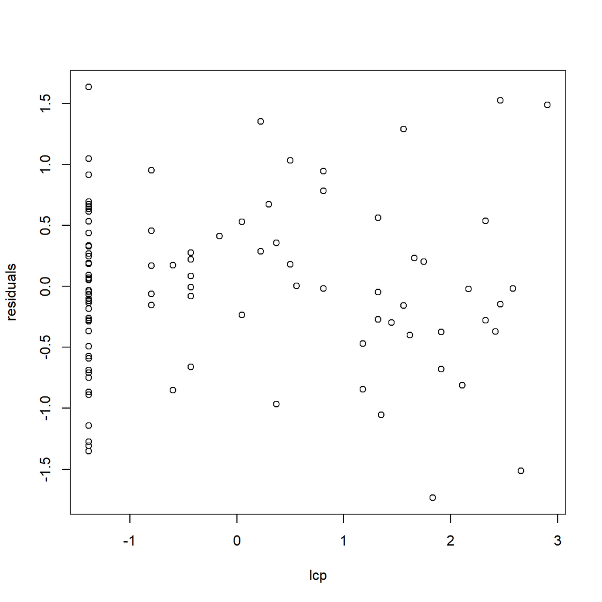

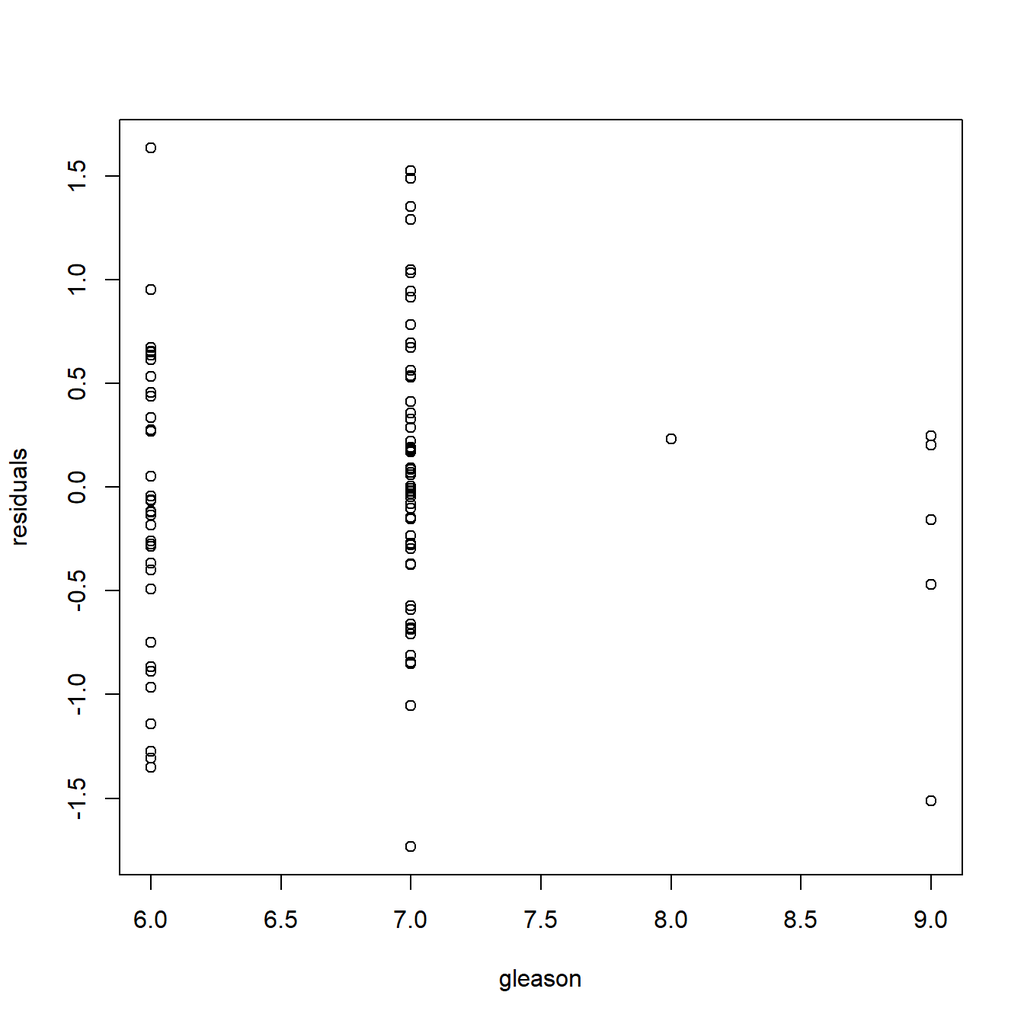

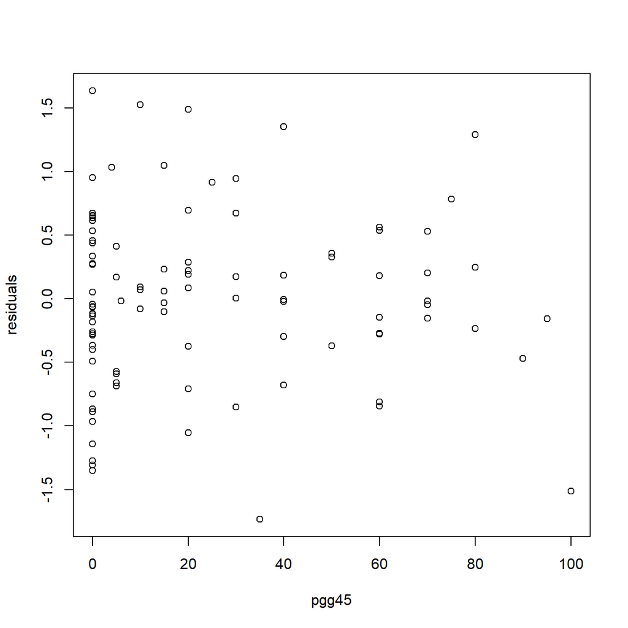

```r
> for (i in 3:8) {
+   plot(prostate[,i],residuals(model),xlab=colnames(prostate)[i],ylab="residuals")
+ }
```

## Problema 6.4. pag. 97

**For the `swiss` data, fit a model with `Fertility` as the response and the other variables as predictors. Answer the questions posed in the first question.**

Este dataset que no habíamos usado en este curso hasta ahora relaciona el índice de fertilidad en 47 provincias suizas de habla francesa hacia el 1888 con diferentes variables socioeconómicas. Se puede encontrar información sobre el significado de las variables en [su página de ayuda](https://stat.ethz.ch/R-manual/R-devel/library/datasets/html/swiss.html).

Cargamos los datos y ajustamos el modelo.

```r
> require(faraway)
```

```r
> data(swiss,package="datasets")
> head(swiss)
```

|  | Fertility | Agriculture | Examination | Education | Catholic | Infant.Mortality |
| --- | --- | --- | --- | --- | --- | --- |
| Courtelary | 80.2 | 17.0 | 15 | 12 | 9.96 | 22.2 |
| Delemont | 83.1 | 45.1 | 6 | 9 | 84.84 | 22.2 |
| Franches-Mnt | 92.5 | 39.7 | 5 | 5 | 93.40 | 20.2 |
| Moutier | 85.8 | 36.5 | 12 | 7 | 33.77 | 20.3 |
| Neuveville | 76.9 | 43.5 | 17 | 15 | 5.16 | 20.6 |
| Porrentruy | 76.1 | 35.3 | 9 | 7 | 90.57 | 26.6 |

```r
> model <- lm(Fertility~.,data=swiss)
> sumary(model)
```

```
                  Estimate Std. Error t value  Pr(>|t|)
(Intercept)      66.915182  10.706038  6.2502 1.906e-07
Agriculture      -0.172114   0.070304 -2.4481  0.018727
Examination      -0.258008   0.253878 -1.0163  0.315462
Education        -0.870940   0.183029 -4.7585 2.431e-05
Catholic          0.104115   0.035258  2.9530  0.005190
Infant.Mortality  1.077048   0.381720  2.8216  0.007336

n = 47, p = 6, Residual SE = 7.16537, R-Squared = 0.71
```

### a) Varianza constante

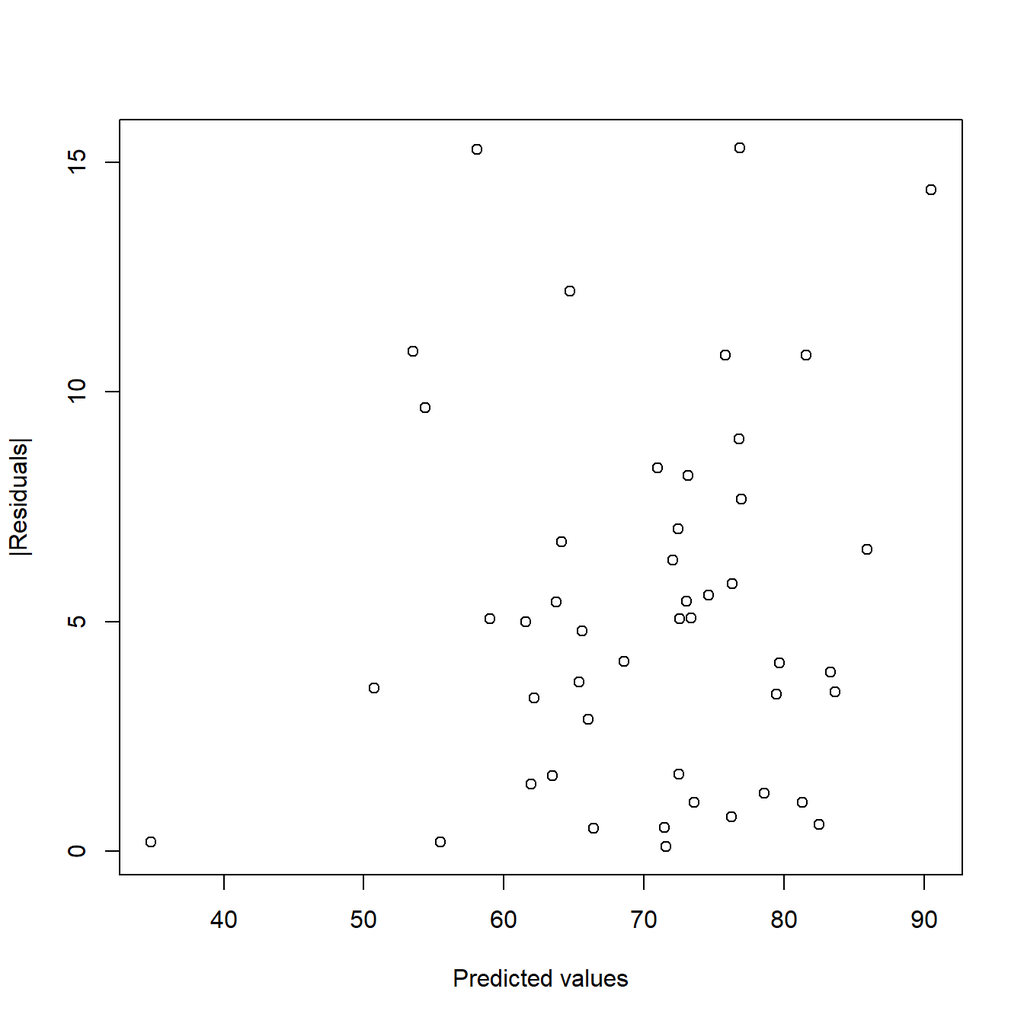

```r
> plot(fitted(model),abs(residuals(model)),xlab="Predicted values",ylab="|Residuals|")
```

```r
> sumary(lm(sqrt(abs(residuals(model)))~fitted(model)))
```

```
              Estimate Std. Error t value Pr(>|t|)
(Intercept)   1.150103   0.949926  1.2107   0.2323
fitted(model) 0.013609   0.013397  1.0159   0.3151

n = 47, p = 2, Residual SE = 0.95417, R-Squared = 0.02
```

No encontramos indicios de heterocedasticidad.

### b) Normalidad

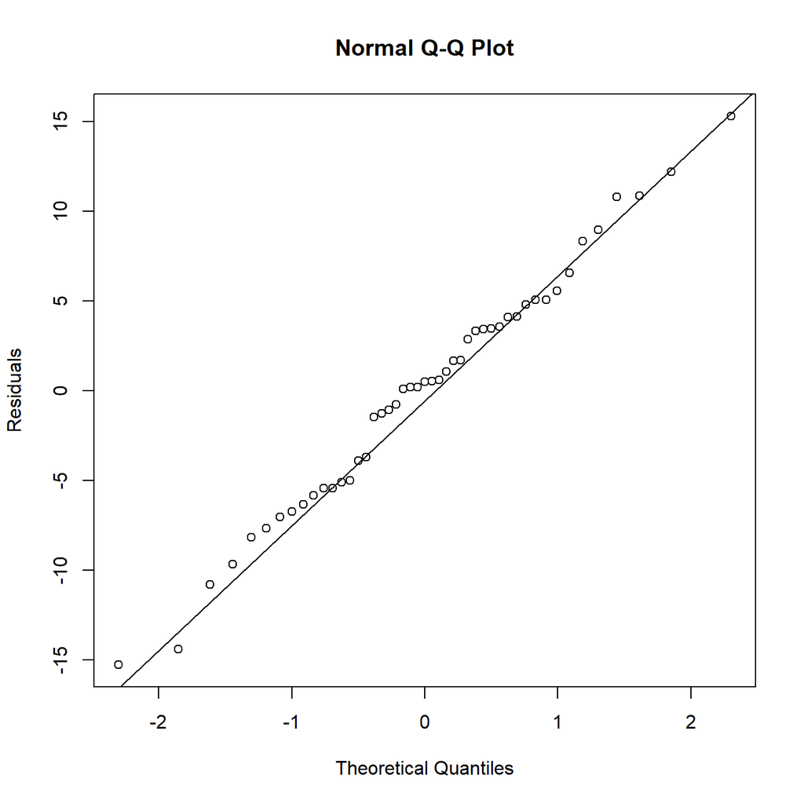

```r
> qqnorm(residuals(model),ylab="Residuals")
> qqline(residuals(model))
```

```r
> shapiro.test(residuals(model))
```

```
    Shapiro-Wilk normality test

data:  residuals(model)
W = 0.98892, p-value = 0.9318
```

No encontramos indicios de falta de normalidad.